# Assess the assocaition between TCR and somatic mutations

Wei Sun

2024-03-10

Here we want to evaluate the consequence of low TCR read-depth

# Setup

## Parameters

```r
chain = params$chain

cat("chain:", chain, "\n")
```

```
## chain: alpha
```

```r
stopifnot(chain == "alpha")
```

## R library and data input

```r
library(data.table)
library(tibble)
library(dplyr)
```

```r
library(ggplot2)
library(ggpointdensity)
library(viridis)
library(foreach)
library(doParallel)
library(qvalue)
library(MASS)
library(ggpubr)
source("_utilities.R")

theme_set(theme_classic())
data_dir = "~/research/data/TCR/TCGA/_processed_data"
```

# Load data

## Read in data

These TCR data have already been aggregated at participant level and a TCR is defined by the aaSeq.

```r
TCR_data   = fread(file.path(data_dir, sprintf("TCR_%s_5.tsv", chain)))
mut_data   = fread(file.path(data_dir, "mutation_freq_geq_5.tsv"))
sample_info = fread(file.path(data_dir, "sample_info_intersection.tsv"))

dim(TCR_data)
```

```
## [1] 21846     4
```

```r
dim(mut_data)
```

```
## [1] 40080     2
```

```r
dim(sample_info)
```

```
## [1] 8463    7
```

```r
head(TCR_data)
```

```
##     Participant          aaSeq chain abundance
## 1: TCGA-61-2016 CAAAGGTSYGKLTF alpha         2
## 2: TCGA-BF-A5EQ CAAAGGTSYGKLTF alpha         2
## 3: TCGA-BR-8486 CAAAGGTSYGKLTF alpha         1
## 4: TCGA-K4-AAQO CAAAGGTSYGKLTF alpha         1
## 5: TCGA-XU-AAXW CAAAGGTSYGKLTF alpha         1
## 6: TCGA-D7-6822     CAAAGNKLTF alpha         1
```

```r
head(mut_data)
```

```
##     participant                    key
## 1: TCGA-02-0003    TP53:17:7577094:G:A
## 2: TCGA-02-0003  PIK3R1:5:67589138:G:A
## 3: TCGA-02-0033    TP53:17:7577538:C:T
## 4: TCGA-02-0033 SLC9C1:3:111887770:C:T
## 5: TCGA-02-0033 PIK3CA:3:178936082:G:A
## 6: TCGA-02-0047  KRT15:17:39673185:C:T
```

```r
head(sample_info)
```

```
##     participant abundance purity T_cell_prop n_mut n_non_silent_mut cancer_type
## 1: TCGA-02-0047         7   0.69  0.04926073    87               63         GBM
## 2: TCGA-02-0055         6   0.55  0.02825506    76               49         GBM
## 3: TCGA-02-2483        10   0.73  0.02388189    70               45         GBM
## 4: TCGA-02-2485        14   0.87  0.02776543    75               52         GBM
## 5: TCGA-02-2486        34   0.72  0.05040473    74               57         GBM
## 6: TCGA-04-1331         8     NA          NA   188              130          OV
```

```r
participants = sample_info$participant

TCR_mat = get_TCR_matrix(TCR_data, participants, dichotomize = FALSE)
mut_mat = get_mut_matrix(mut_data, participants)

stopifnot(setequal(participants, colnames(TCR_mat)))
stopifnot(setequal(participants, colnames(mut_mat)))

TCR_mat = TCR_mat[,match(participants, colnames(TCR_mat))]
mut_mat = mut_mat[,match(participants, colnames(mut_mat))]

dim(TCR_mat)
```

```
## [1] 2333 8463
```

```r
TCR_mat[1:2,1:3]
```

```
##                TCGA-02-0047 TCGA-02-0055 TCGA-02-2483
## CAAAGGTSYGKLTF            0            0            0
## CAAAGNKLTF                0            0            0
```

```r
dim(mut_mat)
```

```
## [1] 5223 8463
```

```r
mut_mat[1:2,1:3]
```

```
##                      TCGA-02-0047 TCGA-02-0055 TCGA-02-2483
## A1CF:10:52595854:G:A            0            0            0
## A1CF:10:52603882:C:T            0            0            0
```

```r
TCR_rd  = sample_info$abundance
TCR_rd2 = colSums(TCR_mat)
summary(TCR_rd)
```

```
##    Min. 1st Qu.  Median    Mean 3rd Qu.    Max.
##     1.0     5.0    16.0    57.4    45.5  4926.0
```

```r
summary(TCR_rd2)
```

```
##     Min.  1st Qu.   Median     Mean  3rd Qu.     Max.
##    0.000    0.000    1.000    4.056    4.000 3262.000
```

```r
table(TCR_rd > 10)
```

```
##
## FALSE  TRUE
##  3336  5127
```

```r
summary(TCR_rd2[TCR_rd <= 10])
```

```
##    Min. 1st Qu.  Median    Mean 3rd Qu.    Max.
##  0.0000  0.0000  0.0000  0.4182  1.0000  7.0000
```

```r
stopifnot(all(TCR_rd >= TCR_rd2))
```

## Check the distribution of TCRs

Some negative binomial regression fail, and thus we use tryCatch here.

```r
tb1 = table(c(TCR_mat))
tb1
```

```
##
##        0        1        2        3        4        5        6        7
## 19724304    15479     2778      753      336      163       84       43
##        8        9       10       11       12       13       14       15
##       45       26       19       20       15        7        6       15
##       16       17       18       19       20       21       22       23
##        5        6        8        6        4        2        3        1
##       24       25       26       27       28       29       30       31
##        4        2        1        4        1        2        2        2
##       32       33       35       36       37       38       39       41
##        1        1        3        1        2        2        2        1
##       43       44       47       49       50       55       56       60
##        1        1        1        1        1        1        1        1
##       64       91       96      103      106      111      116      117
##        1        1        1        1        1        1        1        1
##      128      136      157     3245
##        1        1        1        1
```

```r
(tb1)/sum(tb1)
```

```
##
##            0            1            2            3            4            5
## 9.989934e-01 7.839779e-04 1.406997e-04 3.813782e-05 1.701767e-05 8.255598e-06
##            6            7            8            9           10           11
## 4.254418e-06 2.177857e-06 2.279153e-06 1.316844e-06 9.623089e-07 1.012957e-06
##           12           13           14           15           16           17
## 7.597176e-07 3.545349e-07 3.038870e-07 7.597176e-07 2.532392e-07 3.038870e-07
##           18           19           20           21           22           23
## 4.051827e-07 3.038870e-07 2.025914e-07 1.012957e-07 1.519435e-07 5.064784e-08
##           24           25           26           27           28           29
## 2.025914e-07 1.012957e-07 5.064784e-08 2.025914e-07 5.064784e-08 1.012957e-07
##           30           31           32           33           35           36
## 1.012957e-07 1.012957e-07 5.064784e-08 5.064784e-08 1.519435e-07 5.064784e-08
##           37           38           39           41           43           44
## 1.012957e-07 1.012957e-07 1.012957e-07 5.064784e-08 5.064784e-08 5.064784e-08
##           47           49           50           55           56           60
## 5.064784e-08 5.064784e-08 5.064784e-08 5.064784e-08 5.064784e-08 5.064784e-08
##           64           91           96          103          106          111
## 5.064784e-08 5.064784e-08 5.064784e-08 5.064784e-08 5.064784e-08 5.064784e-08
##          116          117          128          136          157         3245
## 5.064784e-08 5.064784e-08 5.064784e-08 5.064784e-08 5.064784e-08 5.064784e-08
```

```r
pars = matrix(NA, nrow=nrow(TCR_mat), ncol=5)

for(i in 1:nrow(TCR_mat)){
  if(i %% 200 == 0) {cat (i, date(), "\n")}
  yi = TCR_mat[i,]

  gi1 <- tryCatch({
    gi1 = glm.nb(yi ~ log10(TCR_rd + 0.5))
    gi1
    }, error = function(e) {NULL})

  if(is.null(gi1)){ next }

  gi0 = glm.nb(yi ~ 1)
  ai  = anova(gi0, gi1)

  pars[i,1:2] = as.numeric(gi1$coefficients)
  pars[i,3] = gi1$theta
  pars[i,4] = gi1$SE.theta
  pars[i,5] = ai$`Pr(Chi)`[2]
}
```

```
## 200 Sun Mar 10 14:29:26 2024
## 400 Sun Mar 10 14:30:12 2024
## 600 Sun Mar 10 14:30:54 2024
## 800 Sun Mar 10 14:31:43 2024
## 1000 Sun Mar 10 14:32:25 2024
## 1200 Sun Mar 10 14:33:10 2024
## 1400 Sun Mar 10 14:33:51 2024
## 1600 Sun Mar 10 14:34:34 2024
## 1800 Sun Mar 10 14:35:13 2024
## 2000 Sun Mar 10 14:35:52 2024
## 2200 Sun Mar 10 14:36:34 2024
```

```r
colnames(pars) = c("b0", "b1", "theta", "theta_SE", "pval")
dim(pars)
```

```
## [1] 2333    5
```

```r
pars[1:2,]
```

```
##              b0       b1        theta     theta_SE       pval
## [1,] -10.490684 2.054270  0.002275516 2.007549e-03 0.01027190
## [2,]  -9.473207 1.327292 15.483459999 4.979477e+02 0.04442174
```

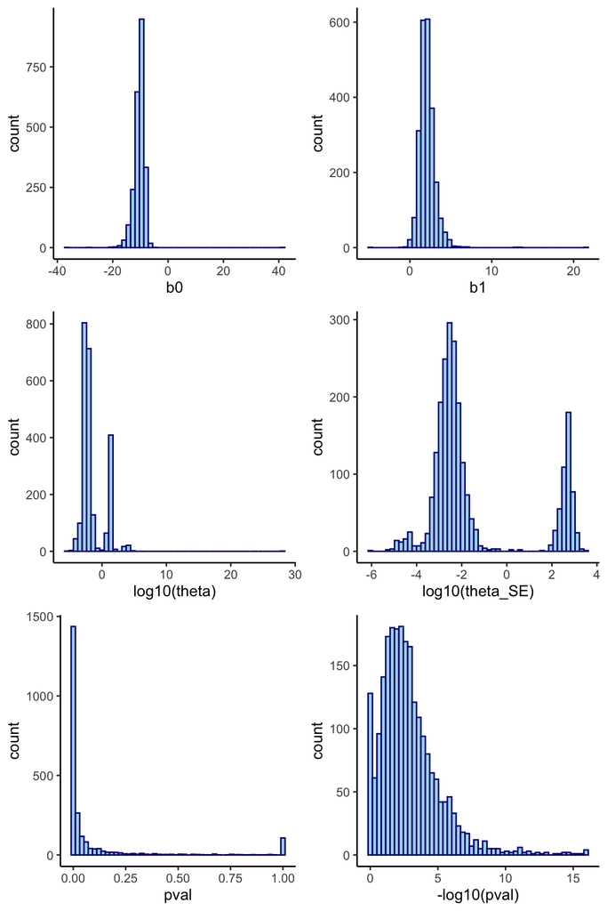

```r
pars = as.data.frame(pars)

glist = list()

for(k in 1:ncol(pars)){
  var_k = names(pars)[k]

  if(var_k == "theta" || var_k == "theta_SE"){
    gk = ggplot(pars, aes(x = log10(.data[[var_k]]))) +
      geom_histogram(bins = 50, fill = "lightblue", color = "darkblue")
  }else{
    gk = ggplot(pars, aes(x = .data[[var_k]])) +
      geom_histogram(bins = 50, fill = "lightblue", color = "darkblue")
  }
  glist[[k]] = gk
}

glist[[6]] = ggplot(pars, aes(x = -log10(pval))) +
  geom_histogram(bins = 50, fill = "lightblue", color = "darkblue")


ggarrange(plotlist = glist, nrow=3, ncol=2)
```

## Scatter plot of nb regression results

By the definition used in glm.nb, variance = $\mu + \mu^2/\theta$, threfore large theta means closer to a Poisson distribution.

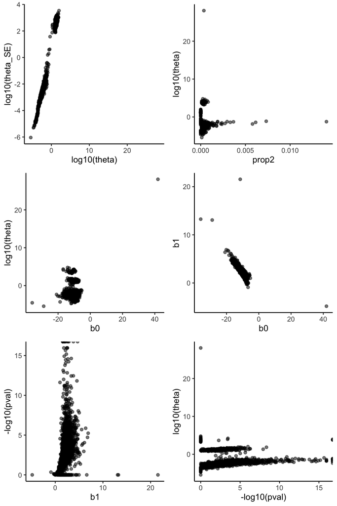

```r
pars$prop2 = rowMeans(TCR_mat > 1)

glist2 = list()
glist2[[1]] = ggplot(data = pars, mapping = aes(x = log10(theta), y = log10(theta_SE))) +
  geom_point(aes(alpha = 0.5)) + theme(legend.position = "none")

glist2[[2]] = ggplot(data = pars, mapping = aes(x = prop2, y = log10(theta))) +
  geom_point(aes(alpha = 0.5)) + theme(legend.position = "none")

glist2[[3]] = ggplot(data = pars, mapping = aes(x = b0, y = log10(theta))) +
  geom_point(aes(alpha = 0.5)) + theme(legend.position = "none")

glist2[[4]] = ggplot(data = pars, mapping = aes(x = b0, y = b1)) +
  geom_point(aes(alpha = 0.5)) + theme(legend.position = "none")

glist2[[5]] = ggplot(data = pars, mapping = aes(x = b1, y = -log10(pval))) +
  geom_point(aes(alpha = 0.5)) + theme(legend.position = "none")

glist2[[6]] = ggplot(data = pars, mapping = aes(x = -log10(pval), y = log10(theta))) +
  geom_point(aes(alpha = 0.5)) + theme(legend.position = "none")

ggarrange(plotlist = glist2, nrow=3, ncol=2)
```

## Check a few TCRs with very large or very small theta

Note that large theta means smaller variance. It seems the theta is small if there are non-zero counts for smaller TCR depth

```r
w_large_theta = which(pars$prop2 > 0 & pars$theta > 100)
w_small_theta = which(pars$prop2 > 0 & pars$theta < 0.01)

length(w_large_theta)
```

```
## [1] 41
```

```r
length(w_small_theta)
```

```
## [1] 1453
```

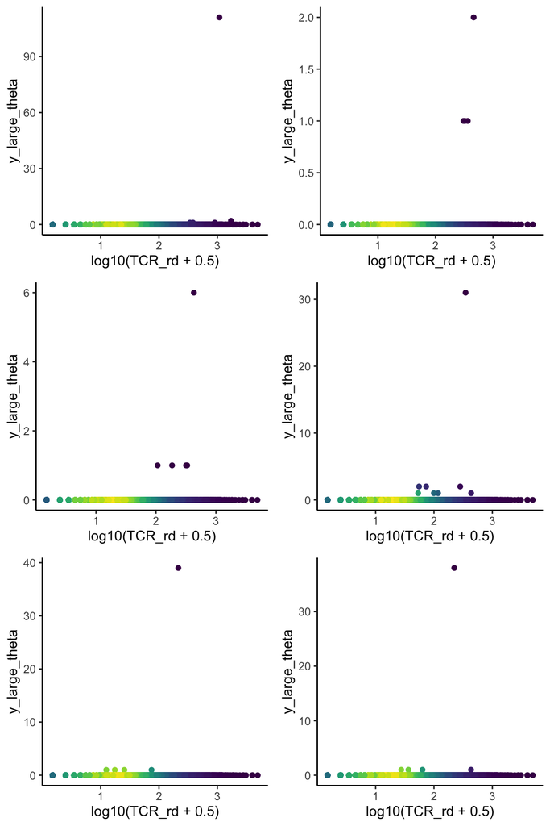

```r
glist_large = glist_small = list()

for(i in 1:6){
  y_large = TCR_mat[w_large_theta[i],]
  y_small = TCR_mat[w_small_theta[i],]

  df1 = data.frame(TCR_rd, y_large_theta = y_large, y_small_theta = y_small)

  glist_large[[i]] = ggplot(data = df1,
                            aes(x = log10(TCR_rd + 0.5), y = y_large_theta)) +
    geom_pointdensity() + scale_color_viridis() + theme(legend.position = "none")

  glist_small[[i]] = ggplot(data = df1,
                            aes(x = log10(TCR_rd + 0.5), y = y_small_theta)) +
    geom_pointdensity() + scale_color_viridis() + theme(legend.position = "none")
}

ggarrange(plotlist = glist_large, nrow=3, ncol=2)
```

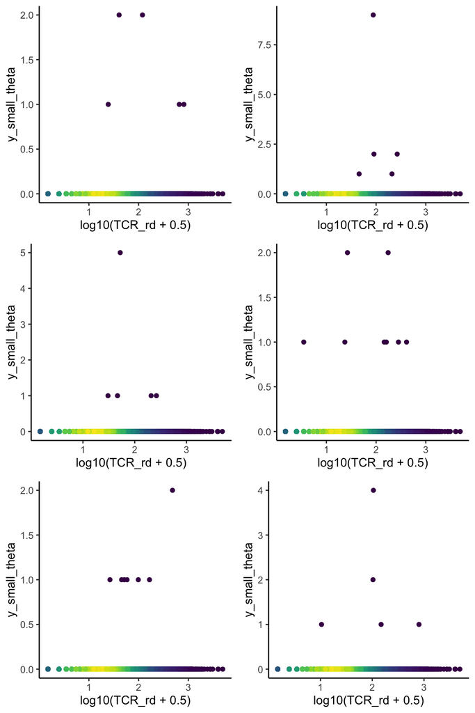

```r
ggarrange(plotlist = glist_small, nrow=3, ncol=2)
```

## Check a few TCRs with large or small slope

There is a strong negative association between b0 and b1. The mean value (reflected by b0) is larger if there are more non-zero counts. When there are more non-zero counts, they are likely observed at lower read-depth, and thus smaller slope b1? That make sense, but it is not clear why the relation between b0 and b1 is stron linear.

```r
quantile(pars$b1, probs = c(0.01, 0.05, 0.95, 0.99), na.rm = TRUE)
```

```
##        1%        5%       95%       99%
## 0.2557780 0.8352069 3.7036141 4.7610472
```

```r
w_large_b1 = which(pars$prop2 > 0 & pars$b1 > 4)
w_small_b1 = which(pars$prop2 > 0 & pars$b1 < 0.8)

length(w_large_b1)
```

```
## [1] 77
```

```r
length(w_small_b1)
```

```
## [1] 57
```

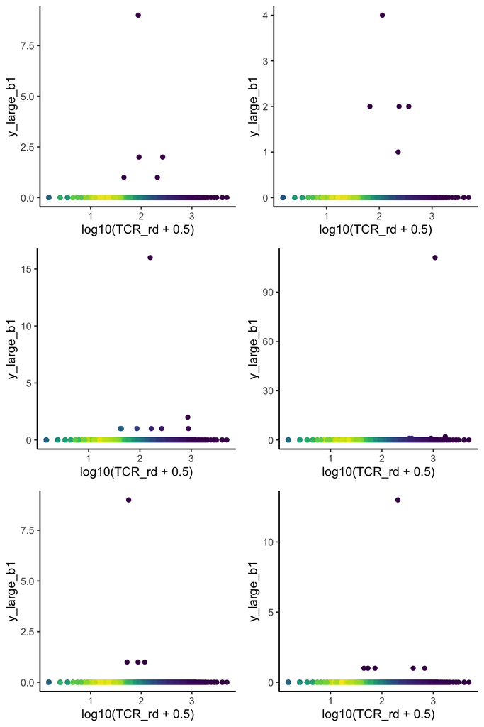

```r
glist_large = glist_small = list()

for(i in 1:6){
  y_large = TCR_mat[w_large_b1[i],]
  y_small = TCR_mat[w_small_b1[i],]

  df1 = data.frame(TCR_rd, y_large_b1 = y_large, y_small_b1 = y_small)

  glist_large[[i]] = ggplot(data = df1,
                            aes(x = log10(TCR_rd + 0.5), y = y_large_b1)) +
    geom_pointdensity() + scale_color_viridis() + theme(legend.position = "none")

  glist_small[[i]] = ggplot(data = df1,
                            aes(x = log10(TCR_rd + 0.5), y = y_small_b1)) +
    geom_pointdensity() + scale_color_viridis() + theme(legend.position = "none")
}

ggarrange(plotlist = glist_large, nrow=3, ncol=2)
```

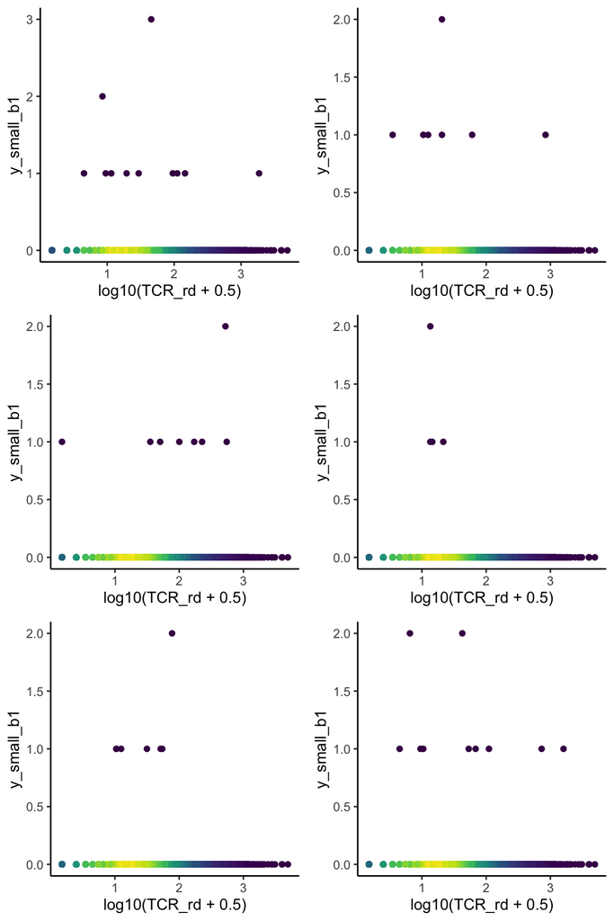

```r
ggarrange(plotlist = glist_small, nrow=3, ncol=2)
```

## Simulate TCR data

Use the results from the following a few examples to guide the simulation.

Results when we restrict the samples with TCR read-depth larger than 10. Note that we only consider alpha chain here.

```
CAGTSGTYKYIF    BRAF:7:140453136:A:T    0.0009
CAVRGTYKYIF      TP53:17:7578442:T:C 4.304067e-06
CAVRGNDYKLSF   PIK3CA:3:178952090:G:C 5.545693e-06
```

When we use all the samples

```
CAVRGTYKYIF      TP53:17:7578442:T:C 1.375570e-06
```

### Check the association strength between somatic mutation and TCR

For simplicity, here we only consider alpha chain

```r
par1 = apply(pars, 2, median, na.rm = TRUE)
par1
```

```
##            b0            b1         theta      theta_SE          pval
## -1.009247e+01  1.991396e+00  5.435599e-03  4.097453e-03  3.285251e-03
##         prop2
##  1.181614e-04
```

```r
dim(TCR_mat)
```

```
## [1] 2333 8463
```

```r
TCR_mat[1:2,1:3]
```

```
##                TCGA-02-0047 TCGA-02-0055 TCGA-02-2483
## CAAAGGTSYGKLTF            0            0            0
## CAAAGNKLTF                0            0            0
```

```r
dim(mut_mat)
```

```
## [1] 5223 8463
```

```r
mut_mat[1:2,1:3]
```

```
##                      TCGA-02-0047 TCGA-02-0055 TCGA-02-2483
## A1CF:10:52595854:G:A            0            0            0
## A1CF:10:52603882:C:T            0            0            0
```

```r
n_mut = rowSums(mut_mat)
summary(n_mut)
```

```
##    Min. 1st Qu.  Median    Mean 3rd Qu.    Max.
##    0.00    5.00    5.00    7.11    7.00  527.00
```

```r
sort(n_mut, decreasing = TRUE)[1:10]
```

```
##   BRAF:7:140453136:A:T PIK3CA:3:178936091:G:A PIK3CA:3:178952085:A:G
##                    527                    235                    229
##   KRAS:12:25398284:C:T PIK3CA:3:178936082:G:A   KRAS:12:25398284:C:A
##                    180                    156                    150
##   IDH1:2:209113112:C:T    TP53:17:7578406:C:T    TP53:17:7577538:C:T
##                    137                    131                     98
##   NRAS:1:115256529:T:C
##                     95
```

```r
# repeat BRAF mutation here since it corresponds to two TCRs

mut2check = c("BRAF:7:140453136:A:T",
              "TP53:17:7578442:T:C", "PIK3CA:3:178952090:G:C")

x_mat = mut_mat[match(mut2check, rownames(mut_mat)),]
dim(x_mat)
```

```
## [1]    3 8463
```

```r
x_mat[1:2,1:4]
```

```
##                      TCGA-02-0047 TCGA-02-0055 TCGA-02-2483 TCGA-02-2485
## BRAF:7:140453136:A:T            0            0            0            0
## TP53:17:7578442:T:C             0            0            0            0
```

```r
rowSums(x_mat)
```

```
##   BRAF:7:140453136:A:T    TP53:17:7578442:T:C PIK3CA:3:178952090:G:C
##                    527                     21                      7
```

```r
# Just check three TCRs here
TCR2check = c("CAGTSGTYKYIF", "CAVRGTYKYIF", "CAVRGNDYKLSF")

y_mat = TCR_mat[match(TCR2check, rownames(TCR_mat)),]
dim(y_mat)
```

```
## [1]    3 8463
```

```r
y_mat[,1:4]
```

```
##              TCGA-02-0047 TCGA-02-0055 TCGA-02-2483 TCGA-02-2485
## CAGTSGTYKYIF            0            0            0            0
## CAVRGTYKYIF             0            0            0            0
## CAVRGNDYKLSF            0            0            0            0
```

```r
rowSums(y_mat)
```

```
## CAGTSGTYKYIF  CAVRGTYKYIF CAVRGNDYKLSF
##           19           12            7
```

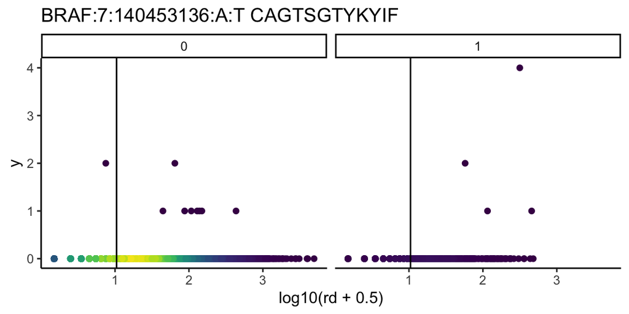

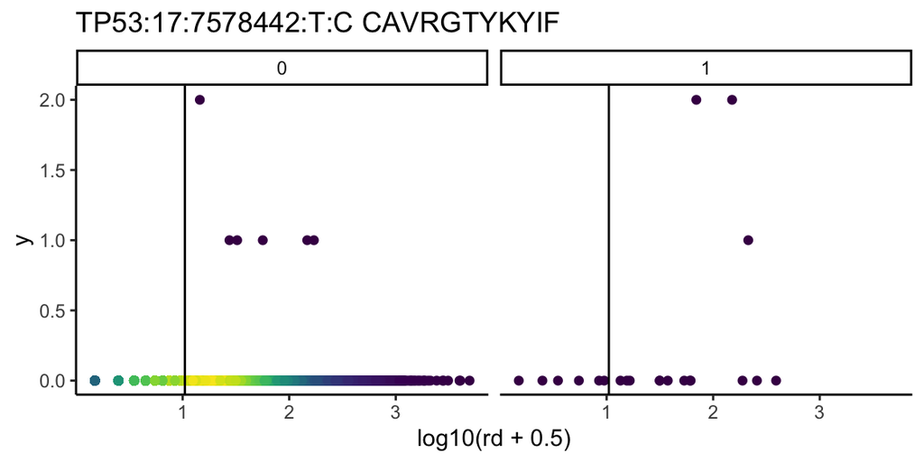

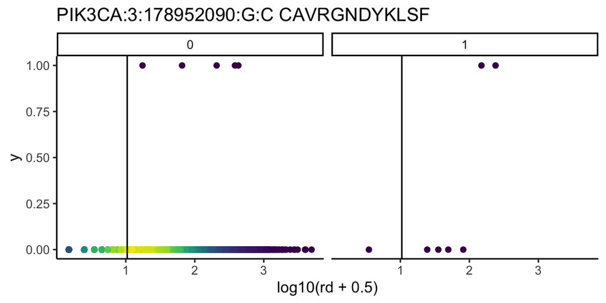

```r
df_res = data.frame(mutation = mut2check[1:3], TCR = TCR2check[1:3],
                    pval=NA, pval_subset=NA, b1=NA, b1_subset=NA)

for(k in 1:3){
  y_k = y_mat[k,]
  x_k = x_mat[k,]

  df_k = data.frame(y=y_k, x=as.factor(x_k), rd = TCR_rd)

  gk  = glm.nb(y ~ log10(rd + 0.5) + x, data=df_k)
  gk0 = glm.nb(y ~ log10(rd + 0.5), data=df_k)
  ak  = anova(gk, gk0)
  df_res$pval[k] = ak$`Pr(Chi)`[2]
  df_res$b1[k] = coef(gk)[["x1"]]

  df_k_sub = df_k[df_k$rd > 10,]
  gk  = glm.nb(y ~ log10(rd + 0.5) + x, data=df_k_sub)
  gk0 = glm.nb(y ~ log10(rd + 0.5), data=df_k_sub)
  ak  = anova(gk, gk0)
  df_res$pval_subset[k] = ak$`Pr(Chi)`[2]
  df_res$b1_subset[k] = coef(gk)[["x1"]]

  gp_k = ggplot(data = df_k, aes(x=log10(rd + 0.5), y=y)) +
    geom_pointdensity() + scale_color_viridis() +
    geom_vline(xintercept = log10(10.5)) +
    theme(legend.position = "none") +
    ggtitle(paste(mut2check[k], TCR2check[k])) +
    facet_wrap(~ x)
  print(gp_k)
}
```

```r
df_res
```

```
##                 mutation          TCR         pval  pval_subset       b1
## 1   BRAF:7:140453136:A:T CAGTSGTYKYIF 1.622020e-02 0.0038302693 1.991385
## 2    TP53:17:7578442:T:C  CAVRGTYKYIF 3.144203e-05 0.0000127139 5.275347
## 3 PIK3CA:3:178952090:G:C CAVRGNDYKLSF 1.794543e-05 0.0000208636 5.779654
##   b1_subset
## 1  2.442997
## 2  5.445781
## 3  5.709591
```

```r
x = x_mat[1,]
sum(x)
```

```
## [1] 527
```

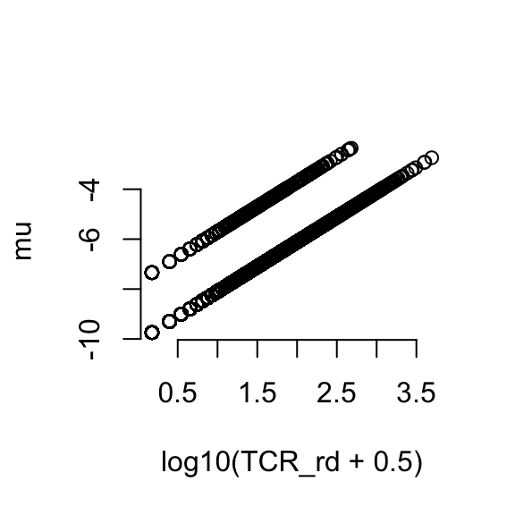

```r
mu = par1["b0"] + par1["b1"]*log10(TCR_rd + 0.5) + 2.4*x
par(bty = "n")
plot(log10(TCR_rd + 0.5), mu)
```

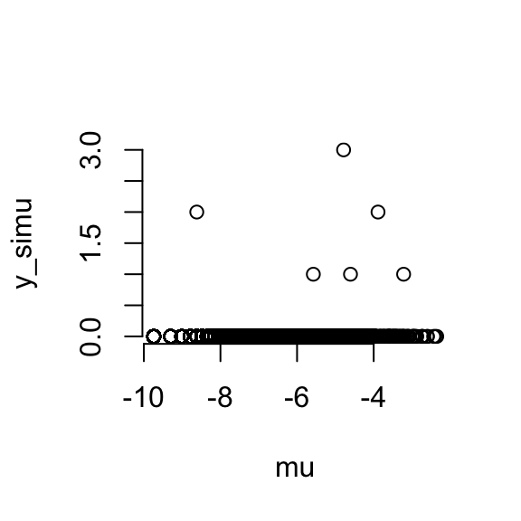

```r
set.seed(39)

stopifnot(length(mu) == ncol(TCR_mat))
y_simu = rnbinom(n=ncol(TCR_mat), mu=exp(mu), size=par1["theta"])
par(bty = "n")
plot(mu, y_simu)
```

```r
set.seed(39)

rd_cutoff = 10
table(TCR_rd > rd_cutoff)
```

```
##
## FALSE  TRUE
##  3336  5127
```

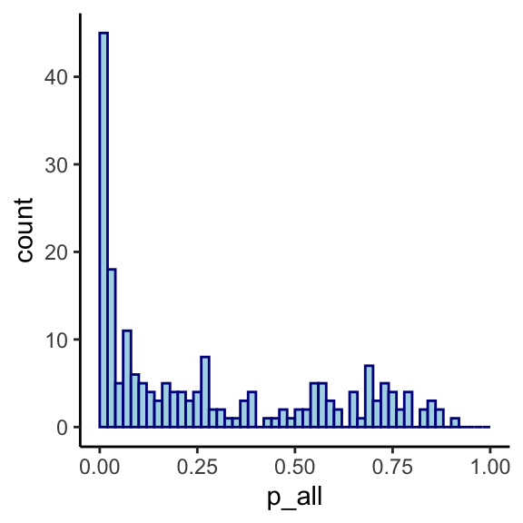

```r
n_simu = 200
pval_df = data.frame(p_all = rep(NA, n_simu), p_subset = rep(NA, n_simu))

for(i in 1:n_simu){
  y_simu = rnbinom(n=ncol(TCR_mat), mu=exp(mu), size=par1["theta"])
  y_all  = as.numeric(y_simu > 0)
  df_i   = data.frame(y = y_all, x = x, rd = TCR_rd)

  l0 = glm(y ~ rd, family = "binomial", data = df_i)
  l1 = glm(y ~ x * rd, family = "binomial", data = df_i)
  lrt = anova(l0, l1, test = "LRT")
  pval_df$p_all[i] = lrt$`Pr(>Chi)`[2]

  df_i_subset = df_i[df_i$rd > rd_cutoff,]
  l0 = glm(y ~ rd, family = "binomial", data = df_i_subset)
  l1 = glm(y ~ x * rd, family = "binomial", data = df_i_subset)
  lrt = anova(l0, l1, test = "LRT")

  pval_df$p_subset[i] = lrt$`Pr(>Chi)`[2]
}

ggplot(pval_df, aes(x = p_all)) +
      geom_histogram(breaks = seq(0,1,by=0.02), fill = "lightblue", color = "darkblue")
```

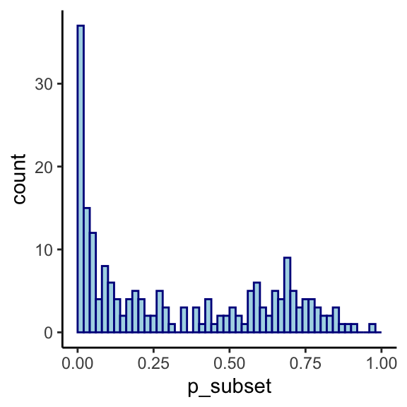

```r
ggplot(pval_df, aes(x = p_subset)) +
      geom_histogram(breaks = seq(0,1,by=0.02), fill = "lightblue", color = "darkblue")
```

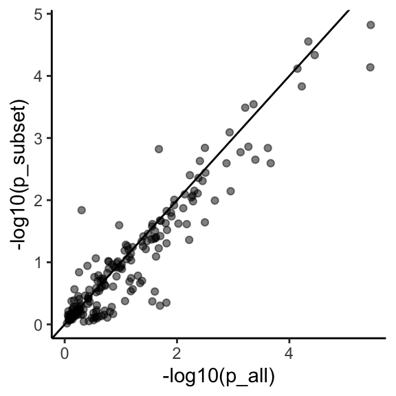

```r
ggplot(pval_df, aes(x = -log10(p_all), y = -log10(p_subset))) +
      geom_point(alpha = 0.5) + geom_abline(slope = 1, intercept = 0)
```

```r
x = x_mat[2,]
sum(x)
```

```
## [1] 21
```

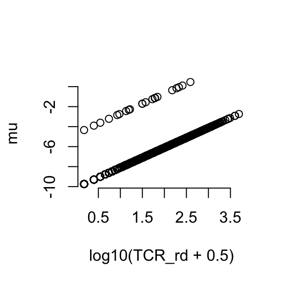

```r
mu = par1["b0"] + par1["b1"]*log10(TCR_rd + 0.5) + 5.4*x
par(bty = "n")
plot(log10(TCR_rd + 0.5), mu)
```

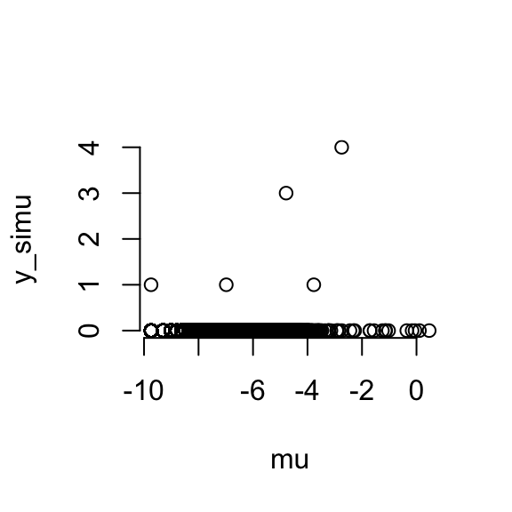

```r
set.seed(39)

stopifnot(length(mu) == ncol(TCR_mat))
y_simu = rnbinom(n=ncol(TCR_mat), mu=exp(mu), size=par1["theta"])
par(bty = "n")
plot(mu, y_simu)
```

```r
set.seed(39)

rd_cutoff = 10
table(TCR_rd > rd_cutoff)
```

```
##
## FALSE  TRUE
##  3336  5127
```

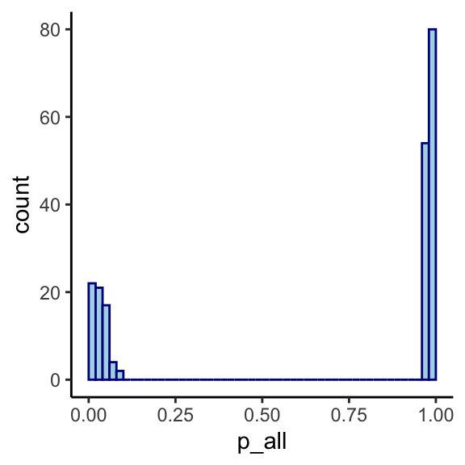

```r
n_simu = 200
pval_df = data.frame(p_all = rep(NA, n_simu), p_subset = rep(NA, n_simu))

for(i in 1:n_simu){
  y_simu = rnbinom(n=ncol(TCR_mat), mu=exp(mu), size=par1["theta"])
  y_all  = as.numeric(y_simu > 0)
  df_i   = data.frame(y = y_all, x = x, rd = TCR_rd)

  l0 = glm(y ~ rd, family = "binomial", data = df_i)
  l1 = glm(y ~ x * rd, family = "binomial", data = df_i)
  lrt = anova(l0, l1, test = "LRT")
  pval_df$p_all[i] = lrt$`Pr(>Chi)`[2]

  df_i_subset = df_i[df_i$rd > rd_cutoff,]
  l0 = glm(y ~ rd, family = "binomial", data = df_i_subset)
  l1 = glm(y ~ x * rd, family = "binomial", data = df_i_subset)
  lrt = anova(l0, l1, test = "LRT")

  pval_df$p_subset[i] = lrt$`Pr(>Chi)`[2]
}

ggplot(pval_df, aes(x = p_all)) +
      geom_histogram(breaks = seq(0,1,by=0.02), fill = "lightblue", color = "darkblue")
```

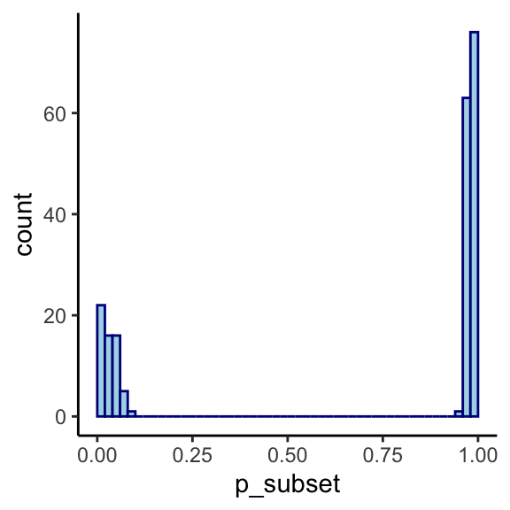

```r
ggplot(pval_df, aes(x = p_subset)) +
      geom_histogram(breaks = seq(0,1,by=0.02), fill = "lightblue", color = "darkblue")
```

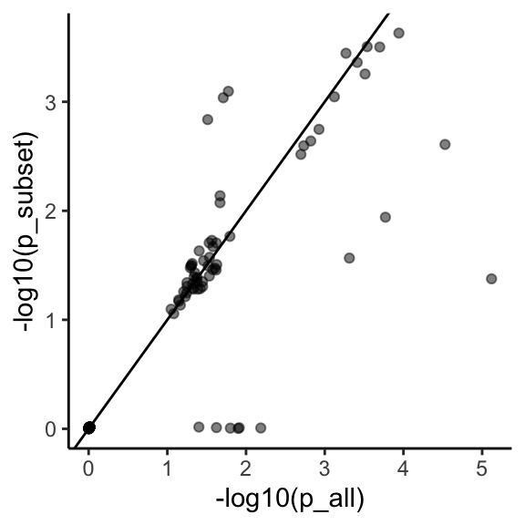

```r
ggplot(pval_df, aes(x = -log10(p_all), y = -log10(p_subset))) +
      geom_point(alpha = 0.5) + geom_abline(slope = 1, intercept = 0)
```

### Simulate data for less frequent mutation of PIK3CA:3:178952090:G:C

```r
x = x_mat[3,]
sum(x)
```

```
## [1] 7
```

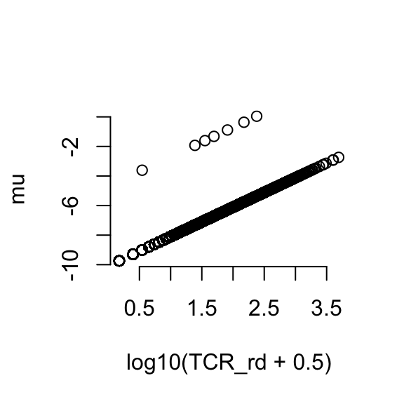

```r
mu = par1["b0"] + par1["b1"]*log10(TCR_rd + 0.5) + 5.4*x
par(bty = "n")
plot(log10(TCR_rd + 0.5), mu)
```

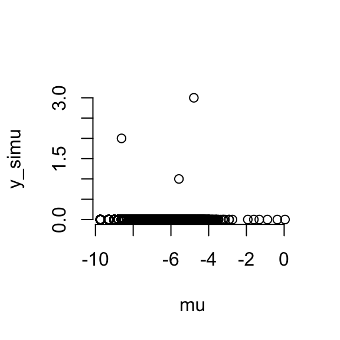

```r
set.seed(39)

stopifnot(length(mu) == ncol(TCR_mat))
y_simu = rnbinom(n=ncol(TCR_mat), mu=exp(mu), size=par1["theta"])
par(bty = "n")
plot(mu, y_simu)
```

```r
set.seed(39)

rd_cutoff = 10
table(TCR_rd > rd_cutoff)
```

```
##
## FALSE  TRUE
##  3336  5127
```

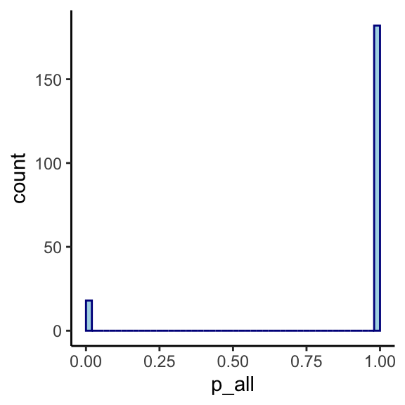

```r
n_simu = 200
pval_df = data.frame(p_all = rep(NA, n_simu), p_subset = rep(NA, n_simu))

for(i in 1:n_simu){
  y_simu = rnbinom(n=ncol(TCR_mat), mu=exp(mu), size=par1["theta"])
  y_all  = as.numeric(y_simu > 0)
  df_i   = data.frame(y = y_all, x = x, rd = TCR_rd)

  l0 = glm(y ~ rd, family = "binomial", data = df_i)
  l1 = glm(y ~ x * rd, family = "binomial", data = df_i)
  lrt = anova(l0, l1, test = "LRT")
  pval_df$p_all[i] = lrt$`Pr(>Chi)`[2]

  df_i_subset = df_i[df_i$rd > rd_cutoff,]
  l0 = glm(y ~ rd, family = "binomial", data = df_i_subset)
  l1 = glm(y ~ x * rd, family = "binomial", data = df_i_subset)
  lrt = anova(l0, l1, test = "LRT")

  pval_df$p_subset[i] = lrt$`Pr(>Chi)`[2]
}

ggplot(pval_df, aes(x = p_all)) +
      geom_histogram(breaks = seq(0,1,by=0.02), fill = "lightblue", color = "darkblue")
```

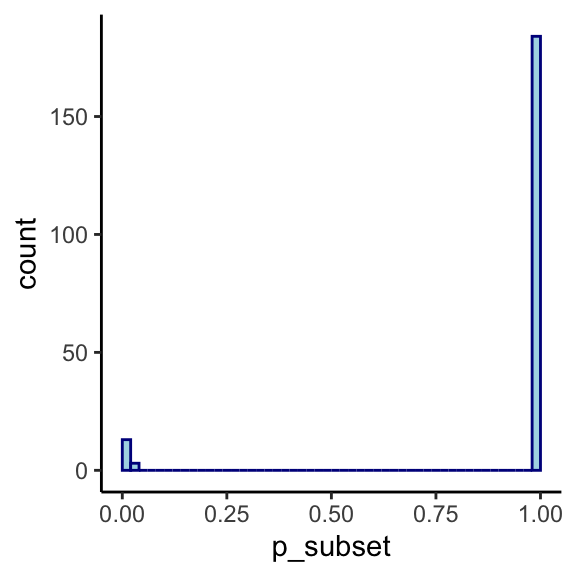

```r
ggplot(pval_df, aes(x = p_subset)) +
      geom_histogram(breaks = seq(0,1,by=0.02), fill = "lightblue", color = "darkblue")
```

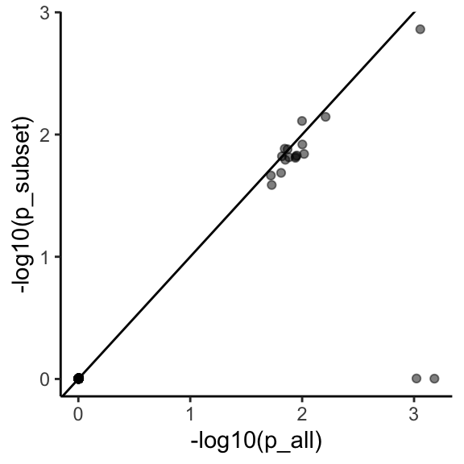

```r
ggplot(pval_df, aes(x = -log10(p_all), y = -log10(p_subset))) +
      geom_point(alpha = 0.5) + geom_abline(slope = 1, intercept = 0)
```

# Session information

```r
gc()
```

```
##            used  (Mb) gc trigger   (Mb) limit (Mb)  max used   (Mb)
## Ncells  1255064  67.1    2864898  153.1         NA   2864898  153.1
## Vcells 67494891 515.0  192750360 1470.6      65536 192750360 1470.6
```